# ds202_hw4

Audrey Comer

3/5/2019

```r
?ChickWeight
library(dplyr)
```

1. Get a frequency breakdown of the number of chicks, their average weight and the standard deviation of the weights in each of the diets at the start of the study. Store the resulting data frame in a variable named weight0 and print.

```r
weight0 <- filter(ChickWeight,Time==0) %>%
  group_by(Diet) %>%
  summarize(
            n_chicks=n(),
            mean_weight = mean(weight),
            sd_weight = sd(weight))
weight0
```

```
## # A tibble: 4 x 4
##   Diet  n_chicks mean_weight sd_weight
##   <fct>    <int>       <dbl>     <dbl>
## 1 1           20        41.4     0.995
## 2 2           10        40.7     1.49
## 3 3           10        40.8     1.03
## 4 4           10        41       1.05
```

2. Each chick should have twelve weight measurements. Use the dplyr package to identify how many measurements are there for each chick. Extract a subset of the data for all chicks with complete information, name the data set complete, and print the first 3 rows. (Hint: you might want to use mutate to introduce a helper variable consisting of the number of observations)

There are 12 measurements for all chicks except 8, 15, 16, 18, and 44.

```r
n1 <- ChickWeight %>% group_by(Chick) %>%
  summarise(n=n()) %>%
  arrange(n, desc(n)) %>%
  filter(n==12)
n2 <- n1$Chick
n2
```

```
##  [1] 13 9  20 10 17 19 4  6  11 3  1  12 2  5  14 7  24 30 22 23 27 28 26
## [24] 25 29 21 33 37 36 31 39 38 32 40 34 35 45 43 41 47 49 46 50 42 48
## 50 Levels: 18 < 16 < 15 < 13 < 9 < 20 < 10 < 8 < 17 < 19 < 4 < ... < 48
```

```r
#if chick shows up in n2 (contains 12 measurements), return it in complete
complete <- ChickWeight %>%
  filter(Chick %in% n2)
head(complete,3)
```

```
##   weight Time Chick Diet
## 1     42    0     1    1
## 2     51    2     1    1
## 3     59    4     1    1
```

3. In the complete data set introduce a new variable that measures the current weight difference compared to day 0. Name this variable weightgain and print the first 3 rows of the new data frame.

```r
dat <- complete %>%
  group_by(Chick) %>%
  mutate(weight_0 = weight[Time == 0])

complete <- complete %>%
  mutate(weightgain = dat$weight-dat$weight_0)
head(complete,3)
```

```
##   weight Time Chick Diet weightgain
## 1     42    0     1    1          0
## 2     51    2     1    1          9
## 3     59    4     1    1         17
```

4. Use {ggplot2} to create side-by-side boxplots of weightgain by Diet for day 21. Describe the relationship in 2-3 sentences. Change the order of the categories in the Diet variable such that the boxplots are ordered by median weightgain, and the lower limit of the y axis should be 0.

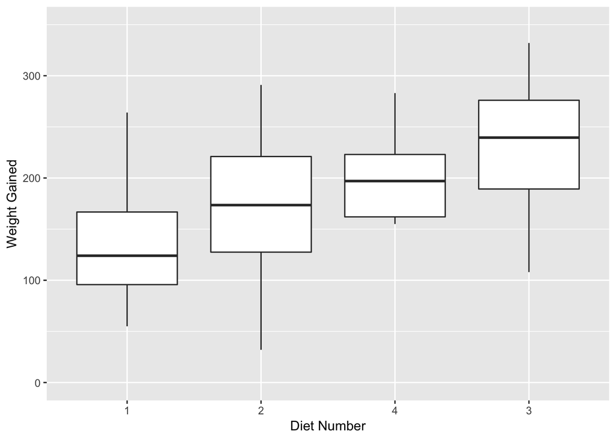

```r
library(ggplot2)
complete %>%
  filter(Time==21) %>%
  ggplot(aes(x=reorder(Diet,weightgain,FUN=median), y=weightgain)) + geom_boxplot() + xlab('Diet Number') +ylab('Weight Gained') + ylim(c(0,350))
```

5. Answer the following question using numerical and graphical summary: Which chick gained the most weight and which gained the least weight? What diets were they on? Chick 24 gained the least; it was on diet 2. Chick 35 gained the most; it was on diet 3.

```r
d5 <-complete %>%
  arrange(desc(weightgain)) %>%
  filter(Time == 21) %>%
  filter(weightgain==max(weightgain) | weightgain==min(weightgain))
#d5 %>%
#  ggplot(aes(x=Chick,y=weightgain)) + geom_bar()
```

6. For the chicks with the least and the most weight at time 0, plot their growth trajectories over time. 5 pts of extra credit: Add to the plot the average growth trajectory for all chicks (calculated as the mean weight for each chick at each time). How do the trajectories compare?

```r
time0<-complete %>%
  filter(Time==0)
df.min<-time0 %>%
  filter(weight==min(weight))
v.min<-df.min$Chick
df.max<-time0 %>%
  filter(weight ==max(weight))
v.max<-df.max$Chick
df.other<- time0 %>%
  filter(weight != max(weight) & weight != min(weight))
v.other<-df.other$Chick

dfplot <- complete
dfplot$Color <- ifelse (complete$Chick %in% v.max, dfplot$Color <-"highest start weight",
        ifelse(complete$Chick %in% v.min,
        dfplot$Color <- "lowest start weight",
        dfplot$Color <- "all others"
        ))
dfplot$Color<- factor(dfplot$Color, levels=c("highest start weight", "lowest start weight", "all others"))
dfplot
```

```
##     weight Time Chick Diet weightgain                Color
## 1       42    0     1    1          0           all others
## 2       51    2     1    1          9           all others
## 3       59    4     1    1         17           all others
## 4       64    6     1    1         22           all others
## 5       76    8     1    1         34           all others
## 6       93   10     1    1         51           all others
## 7      106   12     1    1         64           all others
## 8      125   14     1    1         83           all others
## 9      149   16     1    1        107           all others
## 10     171   18     1    1        129           all others
## 11     199   20     1    1        157           all others
## 12     205   21     1    1        163           all others
## 13      40    0     2    1          0           all others
## 14      49    2     2    1          9           all others
```

[output cut: 526 more lines]

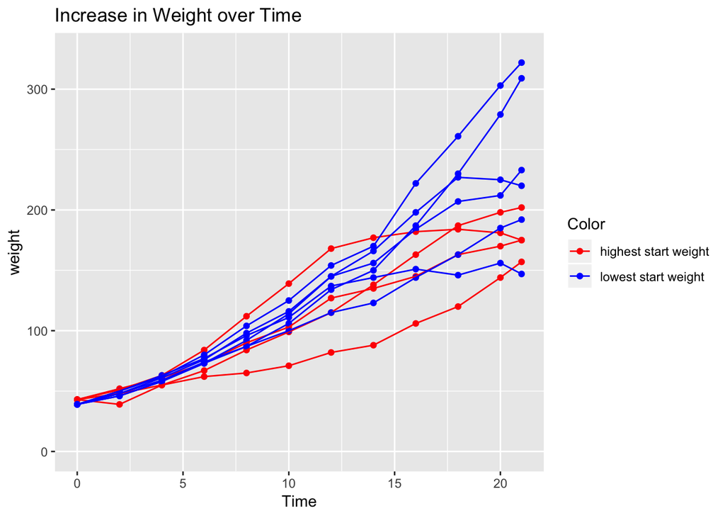

```r
dfplot %>%
  filter(Color!="all others") %>%
  ggplot(aes(x=Time, y=weight, color=Color, group=Chick)) + geom_point() + geom_line() + scale_colour_manual(values=c("red", "blue")) + ggtitle('Increase in Weight over Time') + ylim(0,330)
```

7. What else do you find interesting in the dataset? Show your exploratory analysis.